# Project 1

This assignment makes use of data from a personal activity monitoring device. This device collects data at 5 minute intervals through out the day. The data consists of two months of data from an anonymous individual collected during the months of October and November, 2012 and include the number of steps taken in 5 minute intervals each day.

### Load libraries and set working directory:

```r
library(plyr)
```

```r
library(ggplot2)
library(knitr)
```

### Read Data:

```r
data <- read.csv("activity.csv")
```

## What is mean total number of steps taken per day?

```r
data1<-ddply(na.omit(data), .(date), summarize, tot_steps=sum(steps))
data1
```

```
##          date tot_steps
## 1  2012-10-02       126
## 2  2012-10-03     11352
## 3  2012-10-04     12116
## 4  2012-10-05     13294
## 5  2012-10-06     15420
## 6  2012-10-07     11015
## 7  2012-10-09     12811
## 8  2012-10-10      9900
## 9  2012-10-11     10304
## 10 2012-10-12     17382
## 11 2012-10-13     12426
## 12 2012-10-14     15098
## 13 2012-10-15     10139
## 14 2012-10-16     15084
```

[output cut: 39 more lines]

### Make a histogram of the total number of steps taken each day

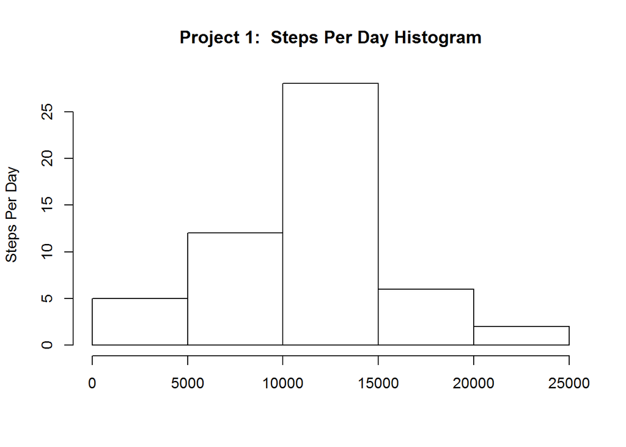

```r
hist(data1$tot_steps, xlab="", ylab="Steps Per Day", main="Project 1:  Steps Per Day Histogram")
```

### Calculate and report the mean and median of the total number of steps taken per day

```r
data2 <- ddply(na.omit(data), c("date"), function(data) return(c(total=sum(data$steps),mean=mean(data$steps), median=median(data$steps))))
data2
```

```
##          date total       mean median
## 1  2012-10-02   126  0.4375000      0
## 2  2012-10-03 11352 39.4166667      0
## 3  2012-10-04 12116 42.0694444      0
## 4  2012-10-05 13294 46.1597222      0
## 5  2012-10-06 15420 53.5416667      0
## 6  2012-10-07 11015 38.2465278      0
## 7  2012-10-09 12811 44.4826389      0
## 8  2012-10-10  9900 34.3750000      0
## 9  2012-10-11 10304 35.7777778      0
## 10 2012-10-12 17382 60.3541667      0
## 11 2012-10-13 12426 43.1458333      0
## 12 2012-10-14 15098 52.4236111      0
## 13 2012-10-15 10139 35.2048611      0
## 14 2012-10-16 15084 52.3750000      0
```

[output cut: 39 more lines]

## What is the average daily activity pattern?

### Make a time series plot of the 5-minute interval (x-axis) and the average number of steps taken, averaged across all days (y-axis)

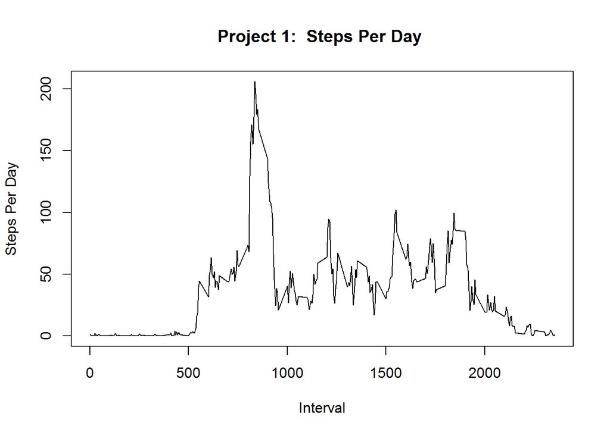

```r
data3 <- ddply(na.omit(data), c("interval"), function(data) return(c(interval_steps_mean=mean(data$steps))))
plot(data3$interval, data3$interval_steps_mean, xlab="Interval", ylab="Steps Per Day", main="Project 1:  Steps Per Day ", type="l")
```

```r
data3[data3$interval== max(data3$interval),]
```

```
##     interval interval_steps_mean
## 288     2355            1.075472
```

```r
intervalmax <- max(data3$interval)
```

## Imputing missing values

### Calculate and report the total number of missing values in the dataset (i.e. the total number of rows with NAs)

```r
NAs <- sum(is.na(data))
NAs
```

```
## [1] 2304
```

### There are 2304 fields with NA values in the data set.

## This is the strategy for replacing NAs with missing data. Data is replaced with means for the same date with NAs being removed.

### These are the steps:

### Get table of means by day from original data but omitting NAs

```r
data4_no_na <- na.omit(data)
data4 <- ddply(data4_no_na, c("date"), function(data4_no_na) return(c(mean=mean(data4_no_na$steps))))
```

### First, append ‘daily’ average column to each ROW by its date in original data set.

### Substitute daily mean for any interval mean with an NA in new data set.

```r
data5 <- merge(data, data4, ALL.x=TRUE)
```

### This replaces the NA in the steps column with the mean for that date from the mean column.

```r
data5$steps <- ifelse(is.na(data5$steps), data5$mean, data5$steps)
```

### Create a new dataset that is equal to the original dataset but with the missing data filled in.

```r
data6 <- (data5[,c("steps","date", "interval")])
```

### Make a histogram of the total number of steps taken each day and Calculate and report the mean and median total number of steps taken per day.

```r
data7 <- ddply(data6, c("date"), function(data6) return(c(total=sum(data6$steps),mean=mean(data6$steps), median=median(data6$steps))))
```

### Histogram of New Data with NAs replaced with means of the same date.

#### Prep Data

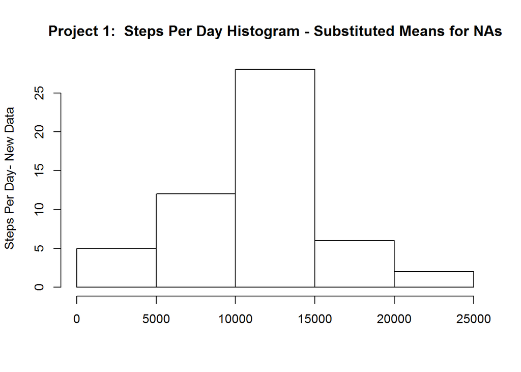

```r
hist(data7$total, xlab="", ylab="Steps Per Day- New Data", main="Project 1:  Steps Per Day Histogram - Substituted Means for NAs")
```

### Histogram of same butwith original data.

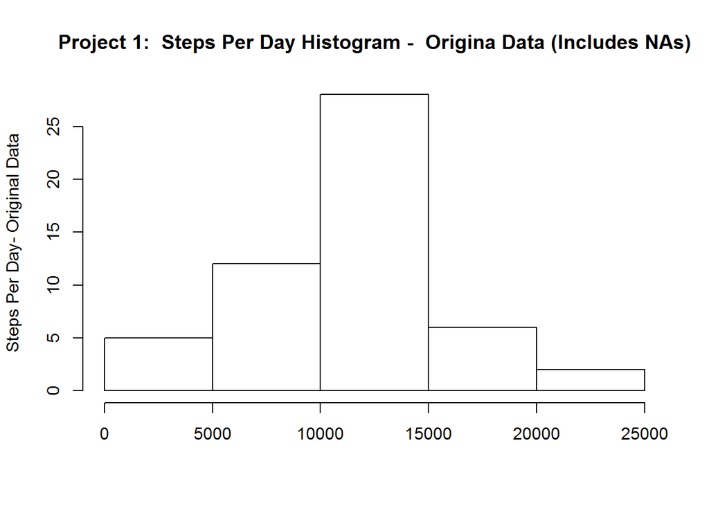

```r
hist(data2$total, xlab="", ylab="Steps Per Day- Original Data", main="Project 1:  Steps Per Day Histogram -  Origina Data (Includes NAs)")
```

#### Do these values (above histograms) differ from the estimates from the first part of the assignment? What is the impact of imputing missing data on the estimates of the total daily number of steps?

#### No, the numbers are the same due to the way I did the NA substitution.

## Are there differences in activity patterns between weekdays and weekends?

### Create a new factor variable in the dataset with two levels - “weekday” and “weekend” indicating whether a given date is a weekday or weekend day.

```r
data6$day_type <- as.factor(ifelse(weekdays(as.Date(data6$date)) %in% c("Sunday", "Saturday"), "Weekend", "Weekday"))
```

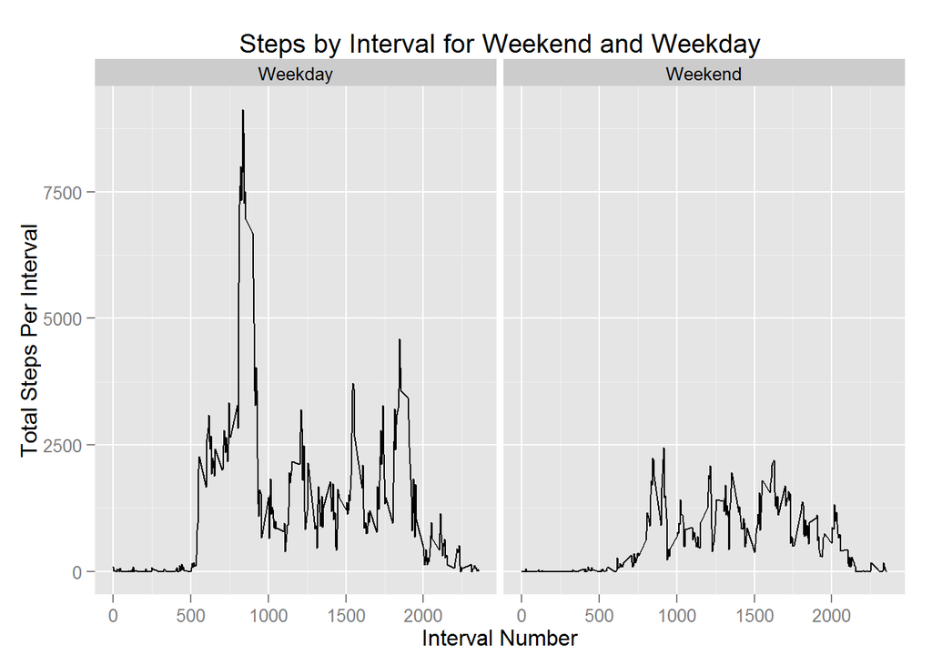

```r
data8 <- ddply(data6, c("day_type", "interval"), function(data6) return(c(total=sum(data6$steps),mean=mean(data6$steps), median=median(data6$steps))))
gg<-ggplot(data8, aes(x=interval, y=total)) + geom_line() + facet_grid(.~day_type)
gg +labs(x="Interval Number",y="Total Steps Per Interval", title="Steps by Interval for Weekend and Weekday")
```